**TIPOLOGIA I CICLE DE VIDA DE LES DADES**  
**Maria Duplà García i Jaume Antolí Plaza**

# 1. DESCRIPCIÓ DEL DATASET

A la industria dels **fons d'inversió** el principal repte és superar el rendiment de l'**índex de referència** que representa el rendiment mig de tots els participants al mercat però segons la [**hipòtesi del mercat eficient**](https://es.wikipedia.org/wiki/Hip%C3%B3tesis_del_mercado_eficiente) i la [**teoria del passeig aleatori**](https://es.wikipedia.org/wiki/Teor%C3%ADa_del_paseo_aleatorio), com tots disposen de la mateixa informació i les cotitzacions bursàtils són aleatòries, ningú no pot superar a llarg termini al seu **índex de referència**.

[La majoria dels **fons d'inversió** no superen a l'**índex de referència**](https://blog.indexacapital.com/tag/gestion-activa/), fet que sembla confirmar la **hipòtesi del mercat eficient** i la **teoria del passeig aleatori**, però hi ha contraexemples com el de [**Jim Simons**](https://es.wikipedia.org/wiki/Jim_Simons) que porta 4 dècades duplicant el rendiment d'inversors de renom com [**Warren Buffett**](https://es.wikipedia.org/wiki/Warren_Buffett).

**Warren Buffett** i el seu mestre [**Benjamin Graham**](https://es.wikipedia.org/wiki/Benjamin_Graham) són els pares de l'anomenat [**anàlisi fonamental**](https://es.wikipedia.org/wiki/An%C3%A1lisis_fundamental), anàlisi qualitatiu basat en dades financeres de l'empresa que segueix sent la base de l'anàlisi de la majoria de gestors de fons.

Si la majoria de gestors fan servir l'**anàlisi fonamental** i la majoria de gestors no superen a l'**índex de referència**, és interessant fixar-se en els gestors que superen a l'**índex de referència** sense fer servir l'**anàlisi fonamental** com és el cas de **Jim Simons**, que va ser el matemàtic que va introduir un **enfocament quantitatiu** a l'**anàlisi bursàtil**.

Així doncs, presentem en aquest dataset un recull de mètriques estadístiques senzilles derivades de la cotització de les accions del **Nasdaq** amb els següents objectius:

- trobar mètriques que presentin alguna capacitat predictiva
- testar el valor predictiu de mètriques com el [**rati de Sharpe**](https://es.wikipedia.org/wiki/Ratio_de_Sharpe)
- testar si les mètriques calculades amb dades diàries són més predictives que les calculades amb dades mensuals
- generar algun model basat en regressions i testar la seva capacitat predictiva
- analitzar si les accions de diferents sectors es comporten de manera similar o no.

Per generar el dataset farem servir la **llibreria ffn** de **Python** per obtenir les següents mètriques calculades per a l'any 2020:

- **start**: inici del període analitzat
- **end**: fi del període analitzat
- **rf**: rendiment de la [tasa lliure de risc](https://es.wikipedia.org/wiki/Tasa_de_inter%C3%A9s_libre_de_riesgo)
- **total_return**: rendiment al període analitzat
- **cagr**: [taxa de creixement anual composta](https://es.wikipedia.org/wiki/Tasa_de_crecimiento_anual_compuesto)
- **max_drawdown**: màxim [drawdown](https://economipedia.com/definiciones/drawdown.html)
- **calmar**: rati del rendiment anualitzat entre el màxim drawdown
- **mtd**: "month to date", rendiment del mes en curs
- **three_month**: rendiment dels darrers tres mesos
- **six_month**: rendiment dels darrers sis mesos
- **ytd**: "year to date", rendiment de l'any en curs
- **one_year**: rendiment del darrer any
- **three_year**: rendiment dels darrers tres anys
- **five_year**: rendiment dels darrers cinc anys
- **ten_year**: rendiment dels darrers deu anys
- **incep**: rendiment de l'acció des de l'inici del període analitzat
- **daily_sharpe**: rati de Sharpe calculat amb dades diàries
- **daily_sortino**: [rati de Sortino](https://zonavalue.com/blog/aprende-a-invertir/ratio-sortino-que-es-y-como-se-interpreta-definicion) calculat amb dades diàries
- **daily_mean**: rendiment diari mitjà
- **daily_vol**: volum de negociació diari mitjà
- **daily_skew**: skewness dels retorns diaris
- **daily_kurt**: kurtosis dels retorns diaris
- **best_day**: retorn diari més alt del període analitzat
- **worst_day**: retorn diari més baix del període analitzat
- **monthly_sharpe**: rati de Sharpe calculat amb dades mensuals
- **monthly_sortino**: rati de Sortino calcula amb dades mensuals
- **monthly_mean**: rendiment mensual mitjà
- **monthly_vol**: volum de negociació mensual mitjà
- **monthly_skew**: skewness dels retorns mensuals
- **monthly_kurt**: kurtosis dels retorns mensuals
- **best_month**: retorn mensual més alt del període analitzat
- **worst_month**: retorn mensual més baix del període analitzat
- **yearly_sharpe**: rati de Sharpe calculat amb dades anuals
- **yearly_sortino**: rati de Sortino calculat amb dades anuals
- **yearly_mean**: rendiment anual mitjà
- **yearly_vol**: volum de negociació anual mitjà
- **yearly_skew**: skewness dels retorns anuals
- **yearly_kurt**: kurtosis dels retorns anuals
- **best_year**: retorn anual més alt del període analitzat
- **worst_year**: retorn anual més baix del període analitzat
- **avg_drawdown**: mitjana de les pèrdues del període analitzat
- **avg_drawdown_days**: mitjana de la duració en dies de les pèrdues del període analitzat
- **avg_up_month**: mitjana dels retorns dels mesos amb retorn positiu
- **avg_down_month**: mitjana dels retorns dels mesos amb retorn negatiu
- **win_year_perc**: percentatge d'anys amb retorn positiu
- **twelve_month_win_perc**: percentatge d'anys amb els dotze mesos amb retorn positiu durant el període analitzat

A continuació generem i mostrem el dataset.

```python
import ffn
import pandas as pd
import yfinance as yf
import numpy as np
import re
import seaborn as sns
import matplotlib
import matplotlib.pyplot as plt
import scipy.stats as ss
from statsmodels.graphics.gofplots import qqplot
from sklearn import linear_model
import warnings
warnings.simplefilter(action='ignore', category=pd.errors.PerformanceWarning)
```

```python
# Descarreguem llista de tickers de les accions del Nasdaq
tickers = pd.read_html('https://en.wikipedia.org/wiki/Nasdaq-100')[3]['Ticker']

# Eliminem les accions que tenen menys d'un any d'històric
tickers_invalids = []
for i in range(len(tickers)):
    data = ffn.get(tickers[i], start='2020-01-01', end='2021-01-01')
    if len(data) < 250:
        tickers_invalids.append(tickers[i])
tickers = tickers.tolist()
for i in tickers_invalids:
    tickers.remove(i)
tickers = pd.Series(tickers)

# Guardem les dades de cada acció
data = ffn.get(tickers, start='2020-01-01', end='2021-01-01')

# Calculem estadístiques de cada acció
perf = data.calc_stats()

# Guardem les dades a un dataframe
dataset = pd.DataFrame()
for ticker in tickers:
    ticker = ticker.lower()
    dataset[ticker] = perf[ticker].stats
dataset = dataset.T

# Mostrem el tamany del dataset
print(f"Tamany del dataset: {dataset.shape}")

# Mostrem el dataset resultant
print("\nMostra de les primeres files del dataset:")
dataset.head()
```

```
Tamany del dataset: (99, 46)

Mostra de les primeres files del dataset:
```

|  | start | end | rf | total_return | cagr | max_drawdown | calmar | mtd | three_month | six_month | ... | yearly_skew | yearly_kurt | best_year | worst_year | avg_drawdown | avg_drawdown_days | avg_up_month | avg_down_month | win_year_perc | twelve_month_win_perc |
| --- | --- | --- | --- | --- | --- | --- | --- | --- | --- | --- | --- | --- | --- | --- | --- | --- | --- | --- | --- | --- | --- |
| atvi | 2020-01-02 | 2020-12-31 | 0 | 0.593532 | 0.596084 | -0.191394 | 3.11444 | 0.168218 | 0.147004 | 0.22332 | ... | NaN | NaN | NaN | NaN | -0.0420634 | 18.75 | 0.0753515 | -0.0337467 | NaN | NaN |
| adbe | 2020-01-02 | 2020-12-31 | 0 | 0.49544 | 0.497508 | -0.256418 | 1.94022 | 0.0452484 | 0.0197582 | 0.148882 | ... | NaN | NaN | NaN | NaN | -0.0343223 | 13.7727 | 0.0888565 | -0.0570259 | NaN | NaN |
| amd | 2020-01-02 | 2020-12-31 | 0 | 0.867821 | 0.871833 | -0.342784 | 2.54338 | -0.0102526 | 0.118551 | 0.743205 | ... | NaN | NaN | NaN | NaN | -0.0801564 | 27.1667 | 0.210852 | -0.0406091 | NaN | NaN |
| algn | 2020-01-02 | 2020-12-31 | 0 | 0.883742 | 0.887843 | -0.537961 | 1.65039 | 0.110308 | 0.632393 | 0.947165 | ... | NaN | NaN | NaN | NaN | -0.0771527 | 22.0667 | 0.135644 | -0.177031 | NaN | NaN |
| googl | 2020-01-02 | 2020-12-31 | 0 | 0.280533 | 0.281621 | -0.308708 | 0.912256 | -0.0010032 | 0.195852 | 0.235951 | ... | NaN | NaN | NaN | NaN | -0.0467307 | 19.8125 | 0.0926963 | -0.0620121 | NaN | NaN |

5 rows × 46 columns

```python
# Exportem les dades a un csv com a dataset inicial.
dataset.to_csv(r'dades_originals.csv')
```

# 2. INTEGRACIÓ I SELECCIÓ DE LES DADES D'INTERÈS A ANALITZAR

Un dels objectius plantejats és analitzar si les accions de diferents **sectors** presenten comportaments similars, així que afegim al dataset una variable que serà el **sector** d'activitat de la corresponent acció.

```python
# Obtenims els sectors de cada acció eliminant les accions amb menys d'un any d'històric
sectors = pd.read_html('https://en.wikipedia.org/wiki/Nasdaq-100')[3]['GICS Sector'].values
tickers_ = pd.read_html('https://en.wikipedia.org/wiki/Nasdaq-100')[3]['Ticker']
df_sectors = pd.DataFrame({"ticker": tickers_, "sector":sectors})
for ticker in tickers_invalids:
    idx = df_sectors[df_sectors["ticker"]==ticker].index
    df_sectors = df_sectors.drop(idx)

# Afegim els sectors al dataframe
dataset["sector"] = df_sectors["sector"].values
```

D'altra banda, si volem analitzar la capacitat predictiva de les variables del dataset haurem d'afegir un **target** que mesuri el rendiment de les accions fora del període analitzat al dataset.

Definim el **target** de la següent manera: rendiment de les accions en el primer trimestre del 2021 entre el rendiment del **Nasdaq** en el mateix període.

Aquesta definició ens permet analitzar en quina mesura cada acció supera (o no) al seu **índex de referència**.

```python
# Calculem el retorn del Nasdaq durant el següent trimestre
ndx = yf.download("NDX", start='2021-01-02', end='2021-04-01', progress=False)
inicial = ndx["Adj Close"][0]
final = ndx["Adj Close"][-1]
nasdaq_return = (final/inicial)-1

# Comparem el retorn de cada acció respecte al Nasdaq com a target
targets = []
for ticker in tickers:
    data = yf.download(ticker, start='2021-01-02', end='2021-04-01', progress=False)
    inicial = data["Adj Close"][0]
    final = data["Adj Close"][-1]
    ren = (final/inicial)-1
    target = ren/nasdaq_return
    targets.append(target)

# Afegim el target al dataset
dataset["target"] = targets
```

Un cop hem integrat les variables **sector** i **target**, procedim a seleccionar les variables que ens interessen, eliminant aquelles que no aporten informació o que són redundants.

Les variables **start** i **end** són comunes a totes les accions perquè per a totes analitzem el mateix període, així que no ens aporten informació.

La variable **rf** és el rendiment de la tasa lliure de risc que la llibrería ffn ha considerat igual a zero i sent comú a totes les variable no ens aporta informació.

Les variables **total_return**, **cagr**, **ytd** i **incep** ens donen la mateixa informació: el rendiment total coincideix amb el CAGR, el YTD i el rendiment des de l'inici del període analitzat perquè el període analitzat és just un any.

De manera que aquestes quatre variables són redundants i podem eliminar-ne tres sense perdre informació.

Les variables **one_year**, **three_year**, **five_year** i **ten_year** fan referència a rendiments en períodes superiors a un any però com el període analitzat és just un any no disposem d'aquesta informació i les podem eliminar.

El mateix succeeix amb les variables **yearly_sharpe**, **yearly_sortino**, **yearly_mean**, **yearly_vol**, **yearly_skew**, **yearly_kurt**, **best_year**, **worst_year**, **win_year_perc** i **twelve_month_win_perc**: són variables que només es calculen si el període analitzat és superior a un any.

Un cop integrades les variables **sector** i **target** i eliminades les variables esmentades obtindrem el dataset amb el què treballarem.

```python
# Eliminem les variables que no ens interessen
eliminades = ['start','end','rf','cagr','ytd','incep','one_year','three_year','five_year','ten_year','yearly_sharpe',
             'yearly_sortino', 'yearly_mean', 'yearly_vol', 'yearly_skew','yearly_kurt','best_year','worst_year',
             'win_year_perc','twelve_month_win_perc']
data = dataset.drop(eliminades, axis=1)

# Mostrem el tamany del dataset
print(f"Tamany del dataset: {data.shape}")

# Mostrem el dataset resultant
print("\nMostra de les primeres files del dataset:")
data.head()
```

```
Tamany del dataset: (99, 28)

Mostra de les primeres files del dataset:
```

|  | total_return | max_drawdown | calmar | mtd | three_month | six_month | daily_sharpe | daily_sortino | daily_mean | daily_vol | ... | monthly_skew | monthly_kurt | best_month | worst_month | avg_drawdown | avg_drawdown_days | avg_up_month | avg_down_month | sector | target |
| --- | --- | --- | --- | --- | --- | --- | --- | --- | --- | --- | --- | --- | --- | --- | --- | --- | --- | --- | --- | --- | --- |
| atvi | 0.593532 | -0.191394 | 3.11444 | 0.168218 | 0.147004 | 0.22332 | 1.39402 | 2.39809 | 0.541514 | 0.388456 | ... | 0.216912 | -0.336925 | 0.168218 | -0.0644842 | -0.0420634 | 18.75 | 0.0753515 | -0.0337467 | Communication Services | 1.103247 |
| adbe | 0.49544 | -0.256418 | 1.94022 | 0.0452484 | 0.0197582 | 0.148882 | 1.07744 | 1.79105 | 0.517089 | 0.479922 | ... | -0.196323 | -1.32989 | 0.155451 | -0.088351 | -0.0343223 | 13.7727 | 0.0888565 | -0.0570259 | Information Technology | -0.657234 |
| amd | 0.867821 | -0.342784 | 2.54338 | -0.0102526 | 0.118551 | 0.743205 | 1.32912 | 2.37035 | 0.808848 | 0.608559 | ... | 1.41623 | 1.95004 | 0.471773 | -0.0972253 | -0.0801564 | 27.1667 | 0.210852 | -0.0406091 | Information Technology | -4.783530 |
| algn | 0.883742 | -0.537961 | 1.65039 | 0.110308 | 0.632393 | 0.947165 | 1.22633 | 2.40868 | 0.877633 | 0.715657 | ... | -0.72597 | 0.42866 | 0.301564 | -0.203343 | -0.0771527 | 22.0667 | 0.135644 | -0.177031 | Health Care | 0.915839 |
| googl | 0.280533 | -0.308708 | 0.912256 | -0.0010032 | 0.195852 | 0.235951 | 0.835442 | 1.3233 | 0.321506 | 0.384834 | ... | -0.386039 | -0.890152 | 0.159 | -0.132388 | -0.0467307 | 19.8125 | 0.0926963 | -0.0620121 | Communication Services | 6.235059 |

5 rows × 28 columns

# 3. NETEJA DE LES DADES

Enllestida la **integració** i la **selecció de dades**, procedim amb el tractament d'**elements buits** i **valors extrems**.

## 3.1. Elements buits

En l'apartat anterior hem eliminat variables que només contenien **elements buits**, ara comprovarem si queden **elements buits** a les variables seleccionades.

```python
# Comprovem els elements buits
data.isnull().sum()
```

```
total_return         0
max_drawdown         0
calmar               0
mtd                  0
three_month          0
six_month            0
daily_sharpe         0
daily_sortino        0
daily_mean           0
daily_vol            0
daily_skew           0
daily_kurt           0
best_day             0
worst_day            0
monthly_sharpe       0
monthly_sortino      0
monthly_mean         0
monthly_vol          0
monthly_skew         0
monthly_kurt         0
best_month           0
worst_month          0
avg_drawdown         0
avg_drawdown_days    0
avg_up_month         0
avg_down_month       0
sector               0
target               0
dtype: int64
```

No hi ha **elements buits** al dataset.

## 3.2. Valors extrems

Definirem els **valors extrems** com aquells valors que superin a la mitjana més o menys 2 desviacions.

Buscarem quants **valors extrems** hi ha per variable i analitzarem si tenen sentit o s'han de tractar.

```python
# Calculem mitjana i desviació i comptem outliers de cada variable
variables = []
mitjanes = []
desviacions = []
minims = []
maxims = []
outliers = []
for column in data.columns:
    if column != "sector":
        mitjana = data[column].mean()
        std = data[column].std()
        minim = data[column].min()
        maxim = data[column].max()
        outlier = 0
        for i in data[column]:
            if i < mitjana-2*std:
                outlier += 1
            if i > mitjana+2*std:
                outlier += 1
        variables.append(column)
        mitjanes.append(mitjana)
        desviacions.append(std)
        minims.append(minim)
        maxims.append(maxim)
        outliers.append(outlier)

# Guardem les dades a un dataframe
df_outliers = pd.DataFrame({"variable": variables, "mitjana": mitjanes, "desviació": desviacions,
                            "mínim": minims, "màxim": maxims, "outliers": outliers})

# Ordenem per número d'outliers i eliminem l'índex
df_outliers = df_outliers.sort_values("outliers", ascending=False)
df_outliers.index=[''] * len(df_outliers)

# Mostrem la mitjana, la desviació i els outliers de cada variable
df_outliers
```

|  | variable | mitjana | desviació | mínim | màxim | outliers |
| --- | --- | --- | --- | --- | --- | --- |
|  | daily_skew | 0.134447 | 0.654924 | -1.247295 | 3.351051 | 8 |
|  | daily_sortino | 1.739285 | 1.220442 | -0.782836 | 5.233352 | 8 |
|  | mtd | 0.057977 | 0.109086 | -0.316027 | 0.555795 | 8 |
|  | monthly_skew | 0.101857 | 0.653017 | -1.410977 | 2.320130 | 7 |
|  | daily_mean | 0.539463 | 0.481697 | -0.232367 | 2.513301 | 7 |
|  | total_return | 0.689782 | 1.108440 | -0.295170 | 7.200506 | 7 |
|  | daily_sharpe | 1.004070 | 0.649046 | -0.479039 | 2.809376 | 6 |
|  | monthly_mean | 0.538402 | 0.515406 | -0.195623 | 2.571971 | 6 |
|  | calmar | 1.921170 | 2.627756 | -0.705567 | 12.457049 | 6 |
|  | avg_down_month | -0.071772 | 0.031196 | -0.177031 | -0.013098 | 5 |
|  | best_day | 0.153230 | 0.059661 | 0.079295 | 0.439739 | 5 |
|  | avg_up_month | 0.110880 | 0.056622 | 0.040568 | 0.355540 | 5 |
|  | monthly_kurt | 0.150751 | 1.380475 | -1.784715 | 7.065859 | 5 |
|  | six_month | 0.318245 | 0.347881 | -0.226193 | 2.267565 | 4 |
|  | three_month | 0.190882 | 0.224345 | -0.282466 | 1.396089 | 4 |
|  | daily_vol | 0.500004 | 0.120812 | 0.291836 | 1.015841 | 4 |
|  | worst_month | -0.140852 | 0.068833 | -0.396694 | -0.013098 | 4 |
|  | monthly_sharpe | 1.248672 | 0.877534 | -0.911711 | 3.418152 | 4 |
|  | avg_drawdown_days | 36.791099 | 53.828868 | 10.481481 | 363.000000 | 4 |
|  | monthly_vol | 0.400348 | 0.180047 | 0.173961 | 1.444015 | 4 |
|  | avg_drawdown | -0.079554 | 0.072939 | -0.608443 | -0.028426 | 3 |
|  | worst_day | -0.142766 | 0.039609 | -0.281666 | -0.063155 | 3 |
|  | best_month | 0.247372 | 0.155833 | 0.085273 | 1.263821 | 3 |
|  | max_drawdown | -0.362146 | 0.088620 | -0.608443 | -0.136479 | 3 |
|  | target | 1.138203 | 4.172440 | -7.347527 | 17.304023 | 3 |
|  | daily_kurt | 6.600704 | 6.051772 | 0.889658 | 48.224736 | 2 |
|  | monthly_sortino | 4.625642 | 7.987651 | -1.776890 | 72.789612 | 1 |

A continuació visualitzarem la distribució de les variables amb més **outliers** amb un **boxplot**.

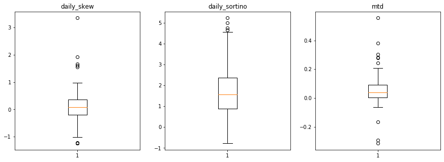

```python
%matplotlib inline

# Recopilem les variables amb més outliers
maxim = df_outliers["outliers"].max()
variables = df_outliers[df_outliers["outliers"]==maxim]["variable"]

# Mostrem boxplot de les variables amb més outliers
fig, axes = plt.subplots(1, 3, figsize= (15,5))

for e,i in enumerate(variables):
    axes[e].boxplot(data[i])
    axes[e].set_title(i)

plt.show()
```

Observant el **boxplot** de les variables amb més **outliers** i els valors màxims i mínims de la taula anterior, concloem que els valors són coherents amb la natura de les variables i no requereixen tractament.

```python
# Transformem les variables numèriques a tipus float
for column in data.columns:
    if column != "sector" and column != "target":
        data[column] = data[column].astype(float)

# Exportem el dataset amb les dades netes
data.to_csv(r'dades_finals.csv')
```

# 4. ANÀLISI DE LES DADES

A continuació procedirem amb les anàlisis pertinents per assolir els objectius establerts:

- trobar mètriques que presentin alguna capacitat predictiva
- testar el valor predictiu de mètriques com el rati de Sharpe
- testar si les mètriques amb dades diàries són més predictives que amb dades mensuals
- generar algun model basat en regressions i testar la seva capacitat predictiva
- analitzar si les accions de diferents sectors es comporten de manera similar o no.

## 4.1. Selecció dels grups de dades

Per a l'objectiu de trobar mètriques que presentin alguna capacitat predictiva farem servir totes les variables per estudiar les correlacions amb el **target**.

Per a l'objectiu de testar el valor predictiu de mètriques com el **rati de Sharpe** compararem les següents mètriques: **calmar**, **daily_sharpe**, **daily_sortino**, **monthly_sharpe** i **monthly_sortino**.

Per a l'objectiu de testar si les mètriques amb dades diàries són més predictives que amb dades mensual compararem els dos grups de mètriques.

En base a l'estudi dels anteriors objectius, construirem un model basat en **regressions**.

Finalment, agruparem les accions per **sector** i analitzarem si tenen mètriques similars. Farem contrastos d'hipòtesis sobre la mitjana de la variable **target** dels diversos sectors. Per a escollir quins sectors compararem amb quins calculem les mitjanes del target per sector i les ordenem.

```python
# Calculem la mitjana del target per sector i ordenem els resultats.
data.groupby("sector")['target'].mean().sort_values(ascending=False)
```

```
sector
Consumer Staples          2.539935
Information Technology    1.577037
Utilities                 1.510017
Communication Services    1.092439
Health Care               0.677151
Industrials               0.354970
Consumer Discretionary   -0.160888
Name: target, dtype: float64
```

Compararem el sector "Consumer Staples" amb la resta, ja que és el que té una mitjana de target més alta.

## 4.2. Comprovació de la normalitat i homogeneïtat de la variància

**VARIABLES**

Per comprovar la **normalitat** de les variables farem servir el **test de Shapiro-Wilk** i el **test D'Agostino**, a més del càlcul de **kurtosis** i **skewness** i la representació gràfica de les distribucions susceptibles de ser considerades com a normals.

```python
# Apliquem el test de Shapiro-Wilk i guardem les dades a un dataframe
variable = []
shapiro_wilk = []
p_value = []
for column in data.columns:
    if column != "sector":
        shapiro_test = ss.shapiro(data[column])
        variable.append(column)
        shapiro_wilk.append(round(shapiro_test[0],4))
        p_value.append(round(shapiro_test[1],4))
df_normalitat = pd.DataFrame({"variable": variable, "Shapiro-Wilk": shapiro_wilk, "p value": p_value})
df_normalitat.index=[''] * len(df_normalitat)

# Mostrem les variables que el test no descarta com a distribucions normals
normals = df_normalitat[df_normalitat["p value"]>0.05]
normals
```

|  | variable | Shapiro-Wilk | p value |
| --- | --- | --- | --- |
|  | max_drawdown | 0.9913 | 0.7778 |
|  | worst_day | 0.9773 | 0.0851 |
|  | monthly_sharpe | 0.9916 | 0.7948 |
|  | monthly_skew | 0.9800 | 0.1360 |

Segons els resultats del **test Shapiro-Wilk**, podem afirmar que totes les variables menys **max_drawdown**, **worst_day**, **monthly_sharpe** i **monthly_skew** tenen distribucions no normals.

Comparem els resultats del **test Shapiro-Wilk** amb els del **test D'Agostino**.

```python
# Apliquem el test de d'Agostino i guardem les dades a un dataframe
variable = []
dagostino = []
p_value = []
for column in data.columns:
    if column != "sector":
        test = ss.normaltest(data[column])
        variable.append(column)
        dagostino.append(round(test[0],4))
        p_value.append(round(test[1],4))
df_normalitat2 = pd.DataFrame({"variable": variable, "D'Agostino": dagostino, "p value": p_value})
df_normalitat2.index=[''] * len(df_normalitat2)

# Mostrem les variables que el test no descarta com a distribucions normals
normals2 = df_normalitat2[df_normalitat2["p value"]>0.05]
normals2
```

|  | variable | D'Agostino | p value |
| --- | --- | --- | --- |
|  | max_drawdown | 1.5927 | 0.4510 |
|  | daily_sharpe | 5.7565 | 0.0562 |
|  | worst_day | 5.2277 | 0.0733 |
|  | monthly_sharpe | 0.5029 | 0.7777 |

Segons els resultats del **test D'Agostino**, podem afirmar que totes les variables menys **max_drawdown**, **daily_sharpe**, **worst_day** i **monthly_sharpe** tenen distribucions no normals.

Així doncs, el **test de Shapiro-Wilk** i el **test D'Agostino** coincideixen en que podem considerar totes les variables com no normals menys **max_drawdown**, **worst_day** i **monthly_sharpe** i discrepen respecte les variables **monthly_week** i **daily_sharpe**.

Analitzem **kurtosis** i **skewness** de les variables amb distribucions normals segons el **test de Shapiro-Wilk** i/o el **test D'Agostino**.

```python
# Llistem les variables normals segons Shapiro-Wilk o D'Agostino
var_normals = normals["variable"].tolist() + normals2["variable"].tolist()
var_normals = np.unique(var_normals).tolist()
var_normals

# Calculem kurtosis i skewness i guardem a un dataframe
variables = []
kurtosis = []
skewness = []
for variable in var_normals:
    variables.append(variable)
    kurtosis.append(ss.kurtosis(data[variable]))
    skewness.append(ss.skew(data[variable]))
df_normalitat3 = pd.DataFrame({"variable": variables, "kurtosis": kurtosis, "skewness": skewness})
df_normalitat3.index=[''] * len(df_normalitat3)

# Mostrem kurtosis i skewness de les variables amb distribució suposadament normal
df_normalitat3
```

|  | variable | kurtosis | skewness |
| --- | --- | --- | --- |
|  | daily_sharpe | 0.226038 | 0.554419 |
|  | max_drawdown | 0.121653 | -0.262991 |
|  | monthly_sharpe | -0.118846 | 0.164443 |
|  | monthly_skew | 0.652987 | 0.527274 |
|  | worst_day | 0.366142 | -0.494248 |

Observem que les variables **monthly_skew** i **daily_sharpe** són les que presenten desviacions més grans i per tant, serien les que més s'allunyen d'una distribució normal.

Comprovem la distribució d'aquestes variables gràficament.

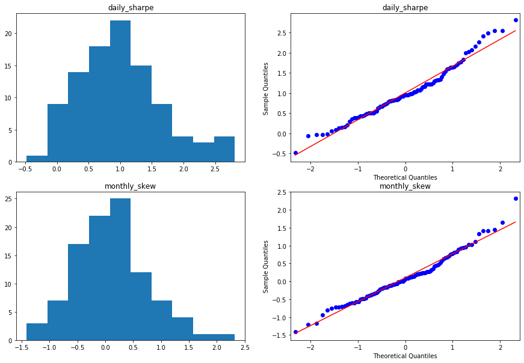

```python
# LListem les variables en les que no coincideixen els tests de Shapiro-Wilk i D'Agostino
set_difference = set(normals["variable"]).symmetric_difference(set(normals2["variable"]))
var_dubte = list(set_difference)

fig, axes = plt.subplots(2, 2, figsize= (15,10))
# Grafiquem aquestes variables en dubte
for e,v in enumerate(var_dubte):
    axes[e,0].hist(data[v])
    axes[e,0].set_title(v)
    qqplot(data[v], dist='norm', line='r', ax=axes[e,1])
    axes[e,1].set_title(v)
plt.show()
```

Les variables **daily_sharpe** i **monthly-skew** presenten les desviacions que ens indicaven els càlculs de **kurtosis** i **skewness**, així que no les assumim com a distribucions normals.

Per tant, considerem com a no normals les distribucions de totes les variables del dataset menys aquelles en les que coincideixen el **test de Shapiro-Wilk** i el **test D'Agostino**: **max_drawdown**, **worst_day** i **monthly_sharpe**.

Abans de considerar la distribució d'aquestes variables com a normals, comprovem gràficament la distribució.

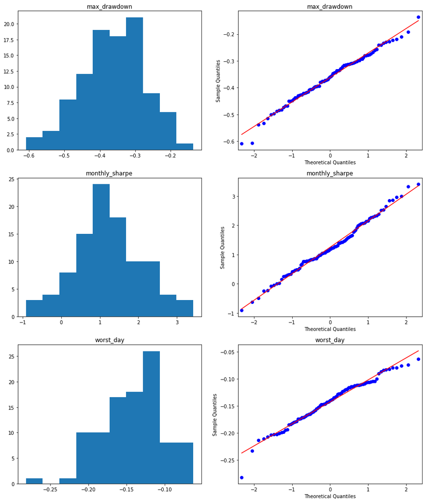

```python
# Llistem les variables que considerem amb distribució normal
for variable in var_dubte:
    variables.remove(variable)

# Grafiquem les variables que considerem amb distribució normal
fig, axes = plt.subplots(3, 2, figsize= (15,18))
for e,v in enumerate(variables):
    axes[e,0].hist(data[v])
    axes[e,0].set_title(v)
    qqplot(data[v], dist='norm', line='r', ax=axes[e,1])
    axes[e,1].set_title(v)
plt.show()
```

Al graficar la distribució s'aprecia un elevat **skewness** a la variable **worst_day** que ens fa considerar com a no normal la distribució d'aquesta variable.

Finalment, concloem que podem descartar la normalitat de la distribució de totes les variables del dataset menys **max_drawdown** i **monthly_sharpe**.

Un cop finalitzat l'anàlisi de normalitat realitzarem l'anàlisi de l'**homogeneïtat de la variància**, també coneguda com **homoscedasticitat**.

Per comprovar l'**homoscedasticitat** i considerant la no normalitat de la majoria de variables, aplicarem el **test de Levene** utilitzant la mediana com a estadístic de la centralitat per a cada variable respecte al **target**.

```python
# Apliquem el test de Levene a totes les variables independents numèriques
variables = []
levene = []
p_value = []
for column in data.columns:
    if column != "sector" and column != "target":
        levene_test = ss.levene(data[column], data["target"], center='median')
        variables.append(column)
        levene.append(levene_test[0])
        p_value.append(levene_test[1])
df_homoscedasticitat = pd.DataFrame({"variable": variables, "Levene": levene, "p value": p_value})
df_homoscedasticitat.index=[''] * len(df_homoscedasticitat)

# Mostrem les variables que mostren homoscedasticitat
homoscedasticitat = df_homoscedasticitat[df_homoscedasticitat["p value"]>0.05]
homoscedasticitat
```

|  | variable | Levene | p value |
| --- | --- | --- | --- |
|  | daily_kurt | 0.013764 | 0.906727 |
|  | monthly_sortino | 0.066928 | 0.796135 |

Segons els **p value** del **test de Levene**, totes les variables presentarien **heterocedasticitat** menys **daily_kurt** i **monthly_sortino**.

**VARIABLE TARGET PER SECTORS**

Aplicarem el **test de Shapiro-Wilk** a la variable **target per sectors** per averiguar si la distribució és normal.

```python
# Creem una llista de sectors
sectors = data['sector'].unique()
shapiro_s = []
p_value_s_s = []
for s in sectors:
    s_ = re.sub(r'\s', '_', s)
    s_ = data.loc[(data['sector'] == s),['target']].values.flatten()
    shapiro_s.append(ss.shapiro(s_)[0])
    p_value_s_s.append(ss.shapiro(s_)[1])

df_normalitat_s = pd.DataFrame({"sector": sectors, "Shapiro-Wilk": shapiro_s, "p value": p_value_s_s})
df_normalitat_s.index=[''] * len(df_normalitat_s)

# Mostrem les variables que el test no descarta com a distribucions normals
normals_s = df_normalitat_s[df_normalitat_s["p value"]>0.05]
normals_s
```

|  | sector | Shapiro-Wilk | p value |
| --- | --- | --- | --- |
|  | Communication Services | 0.917821 | 0.234397 |
|  | Health Care | 0.979462 | 0.981421 |
|  | Consumer Discretionary | 0.962835 | 0.769375 |
|  | Utilities | 0.998581 | 0.928046 |
|  | Industrials | 0.870997 | 0.189390 |
|  | Consumer Staples | 0.902007 | 0.343311 |

Segons els resultats del **test de Shapiro-Wilk**, només es rebutjaria la hipòtesi de distribució normal en el cas dels targets de les accions del sector **Information Technology*.

Ara farem una comprovació visual mitjançant un **qq-plot**.

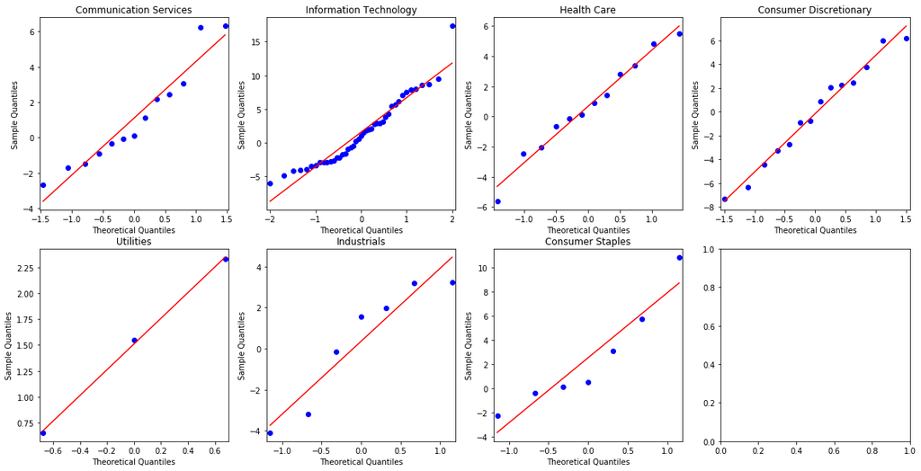

```python
# Mostrem un qq plot per a cada sector
fig, axes = plt.subplots(2, 4, figsize= (20,10))
for e,s in enumerate(sectors):
    s_ = re.sub(r'\s', '_', s)
    s_ = data.loc[(data['sector'] == s),['target']].values.flatten()
    if e < 4:
        qqplot(s_, dist='norm', line='r', ax=axes[0,e])
        axes[0,e].set_title(s)
    else:
        e = e-4
        qqplot(s_, dist='norm', line='r', ax=axes[1,e])
        axes[1,e].set_title(s)
plt.show()
```

**Utilities** compta amb molt poques mostres i **Information Technology**, **Industrials** i **Consumer staples** semblen allunyar-se de la distribució normal.

Podríem considerar que la variable **target** presenta una distribució normal a la resta de sectors i confirmariem el resultat del **test Shapiro-Wilk**.

Ara comprovarem l'homogeneïtat de la variància de la variable **target*** en diferents sectors.

```python
# Calculem les variàncies de les dades
data.groupby("sector")['target'].var()
```

```
sector
Communication Services     8.127363
Consumer Discretionary    18.221746
Consumer Staples          20.172383
Health Care               10.228407
Industrials                8.779288
Information Technology    24.550607
Utilities                  0.699747
Name: target, dtype: float64
```

Comparem la variança de la variable target al sector **Consumer Staples** amb la variança de la resta de sectors.

Per a fer-ho, aplicarem el **test de Levene**.

```python
# Generem l'array de referència per ser el sector amb una mitjana més alta
staples = data.loc[(data['sector'] == 'Consumer Staples'),['target']].values.flatten()

# Apliquem el test de Levene als targets de tots els sectors en referència a "Consumer Staples"
levene_s = []
p_value_s = []
for s in sectors:
    s_ = re.sub(r'\s', '_', s)
    s_ = data.loc[(data['sector'] == s),['target']].values.flatten()
    levene_s.append(ss.levene(staples, s_)[0])
    p_value_s.append(ss.levene(staples, s_)[1])
homoscedasticitat_s = pd.DataFrame({"sectors": sectors, "Levene": levene_s, "p value": p_value_s})
# Mostrem els sectors que mostren homoscedasticitat
homoscedasticitat_s = homoscedasticitat_s[homoscedasticitat_s["p value"]>0.05]
homoscedasticitat_s = homoscedasticitat_s.drop(homoscedasticitat_s.loc[(homoscedasticitat_s['sectors'] == 'Consumer Staples')].index)
homoscedasticitat_s
```

|  | sectors | Levene | p value |
| --- | --- | --- | --- |
| 0 | Communication Services | 0.620875 | 0.440976 |
| 1 | Information Technology | 0.434050 | 0.513156 |
| 2 | Health Care | 0.314538 | 0.582226 |
| 3 | Consumer Discretionary | 0.074708 | 0.787551 |
| 4 | Utilities | 1.439085 | 0.264607 |
| 5 | Industrials | 0.333599 | 0.574225 |

Per tant, deduïm que les variançes són iguals a tots els sectors.

## 4.3. Proves estadístiques

**CAPACITAT PREDICTIVA DE LES VARIABLES**

La matriu de correlacions ens permetrà analitzar les relacions entre les diferents variables i sobretot, les relacions de cada variable amb el **target**.

Considerarem que una variable presenta capacitat predictiva si està correlacionada amb el **target** ja que el **target** és una mesura del rendiment futur de l'acció.

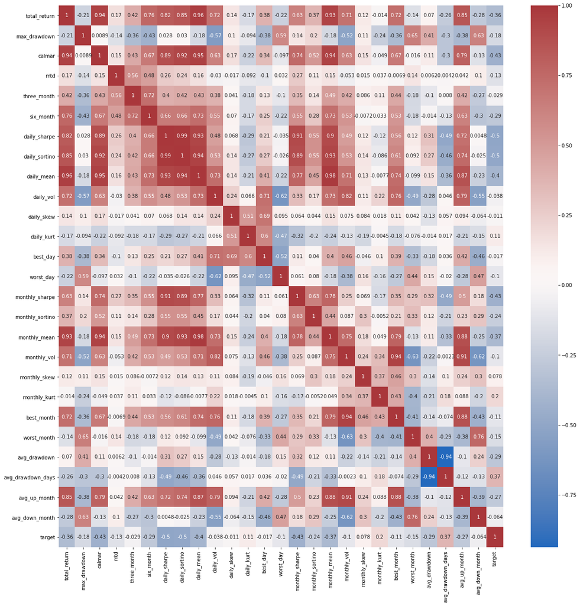

```python
# Generem matriu de correlacions
numeric = data.drop("sector", axis=1)
matriu = numeric.corr()

# Mostrem mapa de calor de la matriu de correlacions
plt.figure(figsize=(20, 20))
sns.heatmap(matriu, annot=True,cmap="vlag")
plt.show()
```

Per facilitar l'estudi de les correlacions, llistem les correlacions més altes.

```python
# Llistem, endrecem i eliminem duplicats de la matriu
parells = matriu.unstack().sort_values()
parells = parells[parells != 1].drop_duplicates()

# Mostrem les correlaciones postives més elevades
df_positives = pd.DataFrame(parells.tail(10), columns=["correlació"])
print("Correlacions positives més elevades:")
df_positives.sort_values("correlació", ascending=False)
```

```
Correlacions positives més elevades:
```

|  |  | correlació |
| --- | --- | --- |
| daily_sharpe | daily_sortino | 0.991677 |
| monthly_mean | daily_mean | 0.982961 |
| daily_mean | total_return | 0.957311 |
| calmar | daily_mean | 0.950858 |
| daily_mean | daily_sortino | 0.944082 |
| monthly_mean | calmar | 0.943733 |
| monthly_vol | best_month | 0.943533 |
| total_return | calmar | 0.940303 |
|  | monthly_mean | 0.933548 |
| monthly_mean | daily_sortino | 0.930082 |

```python
# Mostrem les correlaciones negatives més elevades
df_negatives = pd.DataFrame(parells.head(10), columns=["correlació"])
print("Correlacions negatives més elevades:")
df_negatives
```

```
Correlacions negatives més elevades:
```

|  |  | correlació |
| --- | --- | --- |
| avg_drawdown | avg_drawdown_days | -0.937297 |
| monthly_vol | worst_month | -0.632574 |
| worst_day | daily_vol | -0.623127 |
| monthly_vol | avg_down_month | -0.619641 |
| daily_vol | max_drawdown | -0.568650 |
| avg_down_month | daily_vol | -0.546238 |
| monthly_vol | max_drawdown | -0.517803 |
| best_day | worst_day | -0.515648 |
| daily_sharpe | target | -0.498439 |
| daily_sortino | target | -0.496691 |

Observem variables fortament correlacionades amb elles però no variables correlacionades amb el **target** de manera significativa.

**VALOR PREDICTIU DE MÈTRIQUES COM EL RATI DE SHARPE**

Per a l'objectiu de testar el valor predictiu de mètriques com el **rati de Sharpe** compararem les següents mètriques: **calmar**, **daily_sharpe**, **daily_sortino**, **monthly_sharpe** i **monthly_sortino**.

Primer de tot, veurem en detall les correlacions entre aquestes mètriques.

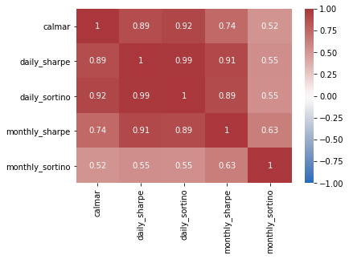

```python
# Seleccionem els ratis que volem estudiar
ratis = data.loc[:,["calmar","daily_sharpe","daily_sortino","monthly_sharpe","monthly_sortino"]]

# Creem el gràfic heatmap
sns.heatmap(ratis.corr(), annot=True, vmin=-1, vmax=1, cmap="vlag")
plt.show()
```

S'observen correlacions elevades entre aquests ratis com era d'esperar entre ratis com el de **Sharpe** i el de **Sortino** al tractar-se de ratis molt similars.

Ara estudiem la correlació d'aquests ratis amb el **target**.

```python
correlacions = []
variables = []
for column in ratis.columns:
    cor = data["target"].corr(data[column])
    variables.append(column)
    correlacions.append(cor)

df_cor_target = pd.DataFrame({"variable": variables, "correlació": correlacions})
df_cor_target.index=[''] * len(df_cor_target)
df_cor_target
```

|  | variable | correlació |
| --- | --- | --- |
|  | calmar | -0.433346 |
|  | daily_sharpe | -0.498439 |
|  | daily_sortino | -0.496691 |
|  | monthly_sharpe | -0.431093 |
|  | monthly_sortino | -0.244679 |

Aquests ratis mesuren el rendiment d'un actiu en funció del risc.

En teoria, les millors accions per invertir serien aquelles que tinguin els ratis més alts.

De fet, **William Sharpe*** va rebre un **Premi Nobel** per les seves contribucions en economia, entre d'altres el **rati de Sharpe**.

Però en contra de l'esperat a priori, aquests ratis mostren una correlació inversa amb el **target**.

**DADES DIÀRIES vs. DADES MENSUALS**

Entre les variables trobem algunes que són calculades en base a dades diàries (per exemple: **daily_sharpe**) i d'altres que són calculades en base a dades mensuals (per exemple: **monthly_sharpe**).

Ens preguntem si les mètriques calculades amb dades diàries prediuen millor que les mètriques calculades amb dades mensuals.

Per analitzar aquesta qüestió, crearem una regressió múltiple amb les mètriques calculades amb dades diàries i una altra regressió múltiple amb les mètriques calculades amb dades mensuals i compararem l'ajust d'aquestes regresssions.

Primer calculem l'ajust de la regressió múltiple amb les variables calculades amb dades diàries.

```python
# Seleccionem les variables calculades amb dades diàries
diaries = data.loc[:,["daily_sharpe","daily_sortino","daily_mean","daily_vol","daily_skew","daily_kurt"]]

# Generem la regressió múltiple amb les variables calculades amb dades diàries
lr_dia = linear_model.LinearRegression()
lr_dia.fit(diaries, data["target"])

# Mostrem l'ajust del model generat amb les variables calculades amb dades diàries
ajust_dia = lr_dia.score(diaries, data["target"])
print(f"Ajust del model generat amb variables calculades amb dades diàries: {round(ajust_dia,4)}")
```

```
Ajust del model generat amb variables calculades amb dades diàries: 0.3453
```

Ara calculem l'ajust de la regressió múltiple amb les variables calculades amb dades mensuals.

```python
# Seleccionem les variables calculades amb dades mensuals
mensuals = data.loc[:,["monthly_sharpe","monthly_sortino","monthly_mean","monthly_vol","monthly_skew","monthly_kurt"]]

# Generem la regressió múltiple amb les variables calculades amb dades mensuals
lr_mes = linear_model.LinearRegression()
lr_mes.fit(mensuals, data["target"])

# Mostrem l'ajust del model generat amb les variables calculades amb dades mensuals
ajust_mes = lr_mes.score(mensuals, data["target"])
print(f"\nAjust del model generat amb variables calculades amb dades mensuals: {round(ajust_mes,4)}")
```

```
Ajust del model generat amb variables calculades amb dades mensuals: 0.226
```

La comparació de l'ajust dels models suggereix que les variables calculades amb dades diàries s'ajusten lleugerament millor que les variables calculades amb dades mensuals.

**REGRESSIÓ**

Arribats a aquest punt, ens plantegem fer un model basat en regressions que s'ajusti al **target**.

Hem vist que no hi ha correlacions fortes entre les variables i el **target** i que els ratis calculats amb dades diàries mostren més correlació amb el **target** que els ratis calculats amb dades mensuals, encara que es tracta d'una correlació inversa, al contrari de l'esperada.

Compararem 3 models amb regressions amb diferents variables:

- model 1: model amb totes les variables
- model 2: model només amb ratis calculats amb dades diàries
- model 3: model només amb les 2 variables amb més correlació positiva amb el target

```python
# model amb totes les variables
x_totes = data.drop(["target","sector"], axis=1)
y = data["target"]
lr_totes = linear_model.LinearRegression()
lr_totes.fit(x_totes, y)
predict_totes = lr_totes.predict(x_totes)

# model només amb ratis diaris
x_diaris = diaries
lr_diaris = linear_model.LinearRegression()
lr_diaris.fit(x_diaris, y)
predict_diaris = lr_diaris.predict(x_diaris)

# model només amb avg_drawdown_days i monthly_kurt
x = data.loc[:,["monthly_kurt","avg_drawdown_days"]]
lr = linear_model.LinearRegression()
lr.fit(x, y)
predict_x = lr.predict(x)
```

Calculem el coeficient de determinació de cada model.

```python
print(f'Coeficient de determinació del model 1 amb totes les variables: {round(lr_totes.score(x_totes, y),2)}')
print(f'Coeficient de determinació del model 2 amb els ratis diaris: {round(lr_diaris.score(x_diaris, y),2)}')
print(f'Coeficient de determinació del model 3 amb els ratis seleccionats: {round(lr.score(x, y),2)}')
```

```
Coeficient de determinació del model 1 amb totes les variables: 0.54
Coeficient de determinació del model 2 amb els ratis diaris: 0.35
Coeficient de determinació del model 3 amb els ratis seleccionats: 0.15
```

El model de regressió amb un coeficient de determinació més alt és el primer amb totes les variables.

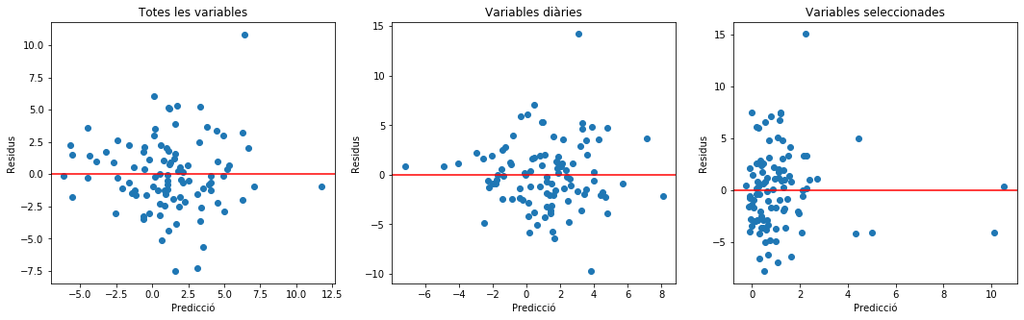

```python
# Calculem els residus per a cada model
residuals_totes = y-predict_totes
residuals_diaris = y-predict_diaris
residuals_x = y-predict_x

# Mostrem els diagrames de residus
fig, axes = plt.subplots(1, 3, figsize= (18,5))
axes[0].scatter(predict_totes, residuals_totes)
axes[0].axhline(y=0, color='r', linestyle='-')
axes[0].set_xlabel("Predicció")
axes[0].set_ylabel("Residus")
axes[0].set_title("Totes les variables")

axes[1].scatter(predict_diaris, residuals_diaris)
axes[1].axhline(y=0, color='r', linestyle='-')
axes[1].set_xlabel("Predicció")
axes[1].set_ylabel("Residus")
axes[1].set_title("Variables diàries")

axes[2].scatter(predict_x, residuals_x)
axes[2].axhline(y=0, color='r', linestyle='-')
axes[2].set_xlabel("Predicció")
axes[2].set_ylabel("Residus")
axes[2].set_title("Variables seleccionades")

plt.show()
```

Observant els diagrames de residus podem confirmar que el millor model és el que contè totes les variables i que el model amb les variables seleccionades és el pitjor.

La regressió amb totes les variables és el model que aconsegueix major correlació amb el target.

**COMPARACIÓ DEL COMPORTAMENT DELS DIFERENTS SECTORS**

Aplicarem una prova de constrast d'hipòtesis per a comprovar si les mitjanes del valor target són iguals entre els diferents sectors.

Farem el contrast del sector **Consumer Staples** amb cadascun dels altres sectors.

Es tracta de parelles de mostres independents amb variànça poblacional desconeguda i igual entre elles.

```python
# Apliquem el test de t-Student als targets de tots els sectors en referència a "Consumer Staples"
statistic_t_s = []
p_value_t_s = []
for s in sectors:
    s_ = re.sub(r'\s', '_', s)
    s_ = data.loc[(data['sector'] == s),['target']].values.flatten()
    statistic_t_s.append(ss.ttest_ind(staples, s_)[0])
    p_value_t_s.append(ss.ttest_ind(staples, s_)[1])
contrast_mean = pd.DataFrame({"sectors": sectors, "estadístic": statistic_t_s, "p value": p_value_t_s})

# Mostrem els sectors per als quals s'indica que la mitjana és igual.
contrast_mean = contrast_mean[contrast_mean["p value"]>0.05]
contrast_mean = contrast_mean.drop(contrast_mean.loc[(contrast_mean['sectors'] == 'Consumer Staples')].index)
contrast_mean
```

|  | sectors | estadístic | p value |
| --- | --- | --- | --- |
| 0 | Communication Services | 0.886077 | 0.387261 |
| 1 | Information Technology | 0.482218 | 0.631843 |
| 2 | Health Care | 1.056727 | 0.305422 |
| 3 | Consumer Discretionary | 1.344266 | 0.194694 |
| 4 | Utilities | 0.381511 | 0.712758 |
| 5 | Industrials | 1.074377 | 0.303783 |

No podem rebutjar en cap cas la hipòtesi nul·la per tant, deduïm que les mitjanes de tots els sectors són iguals.

# 5. REPRESENTACIÓ DELS RESULTATS

**CAPACITAT PREDICTIVA DE LES MÈTRIQUES**

Entre els objectius ens plantejàvem trobar mètriques que presentin capacitat predictiva.

Considerem que si una mètrica presenta capacitat predictiva ha d'estar correlacionada amb el **target**, així que caldrà estudiar la correlació entre cadascuna de les variables i el **target**.

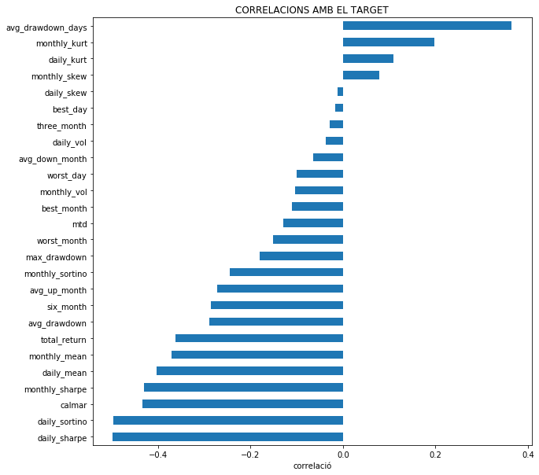

```python
# Llistem les correlacions de les variables amb el target
cor_target = matriu["target"].sort_values()
cor_target = cor_target[cor_target!=1]

# Grafiquem les correlacions amb el target
cor_target.plot(kind = 'barh', figsize=(10,10))
plt.xlabel("correlació")
plt.title("CORRELACIONS AMB EL TARGET")
plt.show()
```

**VALOR PREDICTIU DEL RATI DE SHARPE I SIMILARS**

A l'apartat anterior hem vist que les variables que presenten la correlació més elevada amb el **target** són **daily_sharpe** i **daily_sortino**.

Procedim a graficar la relació d'aquestes variables amb el **target**.

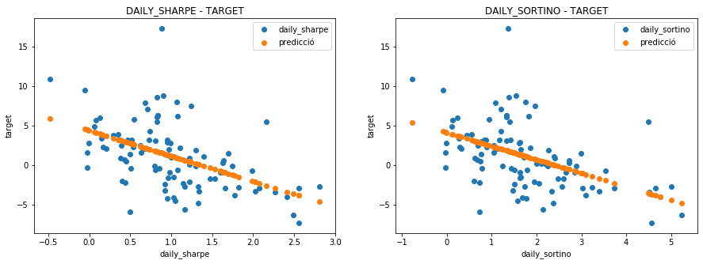

```python
# Calculem regressió lineal amb la variable daily_sharpe
rl = linear_model.LinearRegression()
rl.fit(np.array(data["daily_sharpe"]).reshape(-1, 1), data["target"])
pred = rl.predict(np.array(data["daily_sharpe"]).reshape(-1,1))

fig, axes = plt.subplots(1, 2, figsize= (15,5))

# Grafiquem la relació entre la variable daily_sharpe i el target amb la corresponent regressió
axes[0].scatter(data["daily_sharpe"], data["target"], label="daily_sharpe")
axes[0].scatter(data["daily_sharpe"], pred, label="predicció")
axes[0].set_xlabel("daily_sharpe")
axes[0].set_ylabel("target")
axes[0].legend()
axes[0].set_title("DAILY_SHARPE - TARGET")

# Calculem regressió lineal amb la variable daily_sortino
rl = linear_model.LinearRegression()
rl.fit(np.array(data["daily_sortino"]).reshape(-1, 1), data["target"])
pred = rl.predict(np.array(data["daily_sortino"]).reshape(-1,1))

# Grafiquem la relació entre la variable daily_sortino i el target amb la corresponent regressió
axes[1].scatter(data["daily_sortino"], data["target"], label="daily_sortino")
axes[1].scatter(data["daily_sortino"], pred, label="predicció")
axes[1].set_xlabel("daily_sortino")
axes[1].set_ylabel("target")
axes[1].legend()
axes[1].set_title("DAILY_SORTINO - TARGET")
plt.show()
```

**DADES DIÀRIES vs DADES MENSUALS**

A l'anterior apartat hem vist que una regressió múltiple amb variables calculades amb dades diàries ajusta millor que una regressió múltiple amb variables calculades amb dades mensuals.

Ara mostrarem gràficament l'ajust d'aquests dos models.

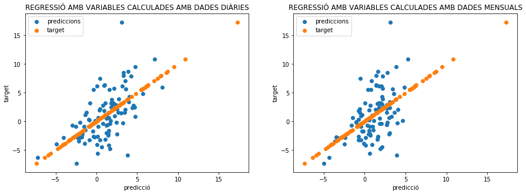

```python
# Fem prediccions per a les variables calculades amb dades diàries
pred_dia = lr_dia.predict(diaries)

fig, axes = plt.subplots(1, 2, figsize= (15,5))

# Grafiquem les prediccions contra els valors reals del target
axes[0].scatter(pred_dia, data["target"], label="prediccions")
axes[0].scatter(data["target"], data["target"], label="target")
axes[0].legend()
axes[0].set_xlabel("predicció")
axes[0].set_ylabel("target")
axes[0].set_title("REGRESSIÓ AMB VARIABLES CALCULADES AMB DADES DIÀRIES")

# Fem prediccions per a les variables calculades amb dades diàries
pred_mes = lr_mes.predict(mensuals)

# Grafiquem les prediccions contra els valors reals del target
axes[1].scatter(pred_mes, data["target"], label="prediccions")
axes[1].scatter(data["target"], data["target"], label="target")
axes[1].legend()
axes[1].set_xlabel("predicció")
axes[1].set_ylabel("target")
axes[1].set_title("REGRESSIÓ AMB VARIABLES CALCULADES AMB DADES MENSUALS")
plt.show()
```

**REGRESSIÓ**

Anteriorment hem vist que la regressió amb totes les variables és el model amb millor ajust.

En cas de confiar en el model, invertiríem en les accions amb les prediccions més altes.

El problema és que l'ajust del model no és gaire alt.

Tanmateix, comprovarem gràficament si invertir en les accions amb les prediccions més altes és millor que invertir en les accions amb les prediccions més baixes.

Per fer-ho dividirem les accions endreçades segons prediccions del model en grups de 11 accions, en total 9 grups de 11 accions.

Si el model és útil, el rendiment mitjà del primer grup hauria de ser millor que el rendiment mitjà del darrer grup.

De fet, el rendiment mitjà de cada grup hauria de ser superior al rendiment mitjà del següent grup.

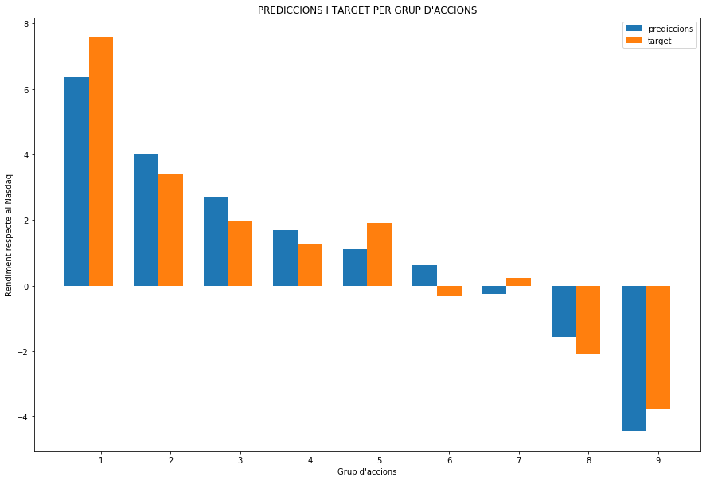

```python
# Endrecem les dades segons valor de la predicció
data["prediccions"] = predict_totes
df_pred = data.sort_values("prediccions", ascending=False)
df_pred = df_pred.loc[:,["prediccions","target"]]

# Calculem la predicció mitjana i el target mitjà de cada grup d'accions
prediccions = []
targets = []
inici = 11
for i in range(9):
    dades = df_pred.iloc[inici*i:(inici*i+11)].mean()
    prediccions.append(dades[0])
    targets.append(dades[1])

# Grafiquem els resultats
barras = np.arange(len(prediccions))
amplada =0.35
plt.figure(figsize=(15,10))
plt.bar(barras, prediccions, width=amplada, label="prediccions")
plt.bar(barras + amplada, targets, width=amplada, label="target")
plt.legend(loc='best')
plt.xticks(barras + amplada, ("1","2","3","4","5","6","7","8","9"))
plt.ylabel("Rendiment respecte al Nasdaq")
plt.xlabel("Grup d'accions")
plt.title("PREDICCIONS I TARGET PER GRUP D'ACCIONS")
plt.show()
```

Efectivament, comprovem que el grup d'accions amb les prediccions més altes aconsegueix el target mitjà més alt i el grup d'accions amb les prediccions més baixes el target mitjà més baix.

Ara comprovarem l'evolució del millor grup d'accions i del pitjor grup d'accions amb l'evolució del Nasdaq durant el primer trimestre del 2021.

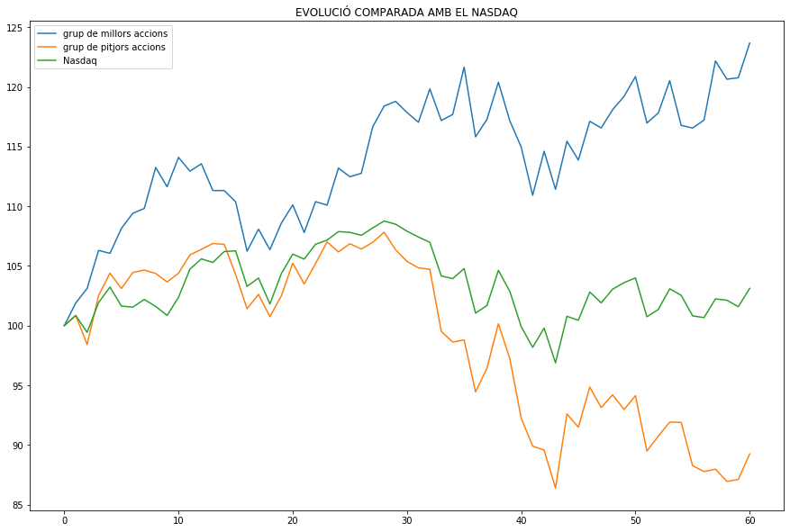

```python
# Llistem el grup d'accions amb les prediccions més elevades
millors = df_pred.iloc[0:11].index.tolist()
millors

# Llistem el grup d'accions amb les prediccions més baixes
pitjors = df_pred.iloc[87:98].index.tolist()

# Calculem l'evolució del Nasdaq
nasdaq = yf.download("NDX", start='2021-01-02', end='2021-04-01', progress=False)
nasdaq["returns"] = nasdaq["Adj Close"].pct_change()
inici = 100
evolucio_nasdaq = [100]
for i in nasdaq["returns"].iloc[1:]:
    inici = inici*(1+i)
    evolucio_nasdaq.append(inici)

# Calculem l'evolució del grup d'accions amb les prediccions més elevades
millors_accions = yf.download(millors, start='2021-01-02', end='2021-04-01', progress=False)["Adj Close"]
df_millors = pd.DataFrame()
for i in millors:
    x = millors_accions[i.upper()].pct_change()
    inici = 100
    evolucio_x = [100]
    for j in x.iloc[1:]:
        inici = inici*(1+j)
        evolucio_x.append(inici)
    df_millors[i] = evolucio_x
df_millors["mitjana"] = df_millors.mean(axis=1)

# Calculem l'evolució del grup d'accions amb les prediccions més baixes
pitjors_accions = yf.download(pitjors, start='2021-01-02', end='2021-04-01', progress=False)["Adj Close"]
df_pitjors = pd.DataFrame()
for i in pitjors:
    x = pitjors_accions[i.upper()].pct_change()
    inici = 100
    evolucio_x = [100]
    for j in x.iloc[1:]:
        inici = inici*(1+j)
        evolucio_x.append(inici)
    df_pitjors[i] = evolucio_x
df_pitjors["mitjana"] = df_pitjors.mean(axis=1)

# Grafiquem l'evolució
plt.figure(figsize=(15,10))
plt.plot(df_millors["mitjana"], label="grup de millors accions")
plt.plot(df_pitjors["mitjana"], label="grup de pitjors accions")
plt.plot(evolucio_nasdaq, label="Nasdaq")
plt.title("EVOLUCIÓ COMPARADA AMB EL NASDAQ")
plt.legend()
plt.show()
```

**COMPORTAMENT DELS DIFERENTS SECTORS**

Mostrem gràficament la distribució de la variable target segons els diferents sectors.

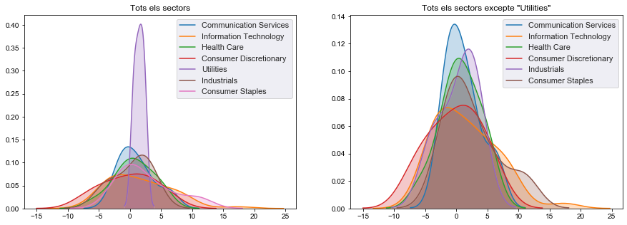

```python
fig, axes = plt.subplots(1, 2, figsize= (15,5))
sns.set(style="darkgrid")

# Creem el gràfic
for s in sectors:
    s_ = re.sub(r'\s', '_', s)
    s_ = data.loc[(data['sector'] == s),['target']].values.flatten()
    fig = sns.kdeplot(s_, shade=True, label=s, ax=axes[0])
axes[0].set_title('Tots els sectors')

# Creem un array sense "Utilities"
idx = np.where(sectors == 'Utilities')
sectors2 = np.delete(sectors, idx)

# Creem el gràfic
for s in sectors2:
    s_ = re.sub(r'\s', '_', s)
    s_ = data.loc[(data['sector'] == s),['target']].values.flatten()
    fig = sns.kdeplot(s_, shade=True, label=s, ax=axes[1])
axes[1].set_title('Tots els sectors excepte "Utilities"')

plt.show()
```

Per veure més detalls de la distribució de la variable target per sectors podem visualitzar les dades amb un boxplot.

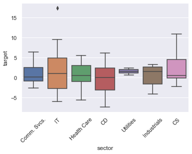

```python
# Assignem el color gris al fons
sns.set(style="darkgrid")
labels = ['Comm. Svcs.', 'IT', 'Health Care', 'CD', 'Utilities', 'Industrials', 'CS']

# Creem el gràfic box plot per sectors
#ax = sns.boxplot(x=data['sector'], y=data['target'])
ax = sns.boxplot(
    x='sector',
    y='target',
    data=data)
ax.set_xticklabels(labels, rotation=45)
plt.show()
```

Mirant els gràfics de densitat i de caixa sembla que tots els sectors tenen una distribució semblant.

El més diferent visualment és **Utilities**, però tampoc li podem donar gaire pes a la nostra anàlisi perquè, com hem vist abans, hi ha molt poques dades d'aquest sector.

# 6. CONCLUSIONS

Anirem valorant les conclussions que hem tret per a cadascun dels objectius que ens hem plantejat.

**CAPACITAT PREDICTIVA DE LES VARIABLES**

En l'estudi de correlacions no hem trobat correlacions significatives amb el **target**, cap supera un valor absolut de 0.5.

De fet, les correlacions més importants que hem trobat, malgrat no ser significatives, són sorprenents: hi ha certa correlació inversa entre els ratis de **Sharpe** i **Sortino*** amb el target.

Tant al heatmap de l'apartat 4.3 com al gràfic de l'apartat 5 es veu clarament la magnitut d'aquestes correlacions.

**VALOR PREDICTIU DEL RATI DE SHARPE I SIMILARS**

Tant el **rati Sharpe**, com altres mesures del rendiment en funció del risc, com **calmar** o **Sortino** presenten diferents graus de correlacions inverses amb el **target**.

Els ratis **daily_sharpe** i **daily_sortino** presenten els ratis de correlació més alt, -0,498 i - 0,496.

En teoria, hauria d'haver una correlació positiva entre aquests ratis i el rendiment futur de les accions però ens trobem amb just el contrari: la correlació entre aquest ratis i el rendiment futur de les accions és inversa.

Aquesta és una conclusió sorprenent ja que el **rati de Sharpe** és un rati àmpliament utilitzat a la indústria dels fons d'inversió.

**DADES DIÀRIES vs DADES MENSUALS**

Després de comparar models de regressions lineals fets amb les diverses mètriques diàries i mensuals arribem a la conclusió de que les mètriques diàries generen un model lleugerament millor, tot i que el coeficient de determinació és només 0,345.

**MODEL DE REGRESSIÓ**

Hem creat tres models de regressió diferents: un amb totes les dades, un altre amb les mètriques diàries i un altre amb variables que mostraven un coeficient de correlació positiu amb el **target**.

Un cop comparats tots tres models fent servir els coeficients de determinació i un estudi de residus, podem concloure que el millor model és el que hem creat amb totes les variables.

A l'apartat 5 hem vist dues gràfiques que ens proporcionen una manera alternativa de valorar la bondat del nostre millor model.

En el primer dividim les accions en grups i les ordenem pel valor de les prediccions.

Al gràfic comparem la nostra predicció amb el **target**.

Veiem que s'apropa força i que l'ordre del target i de les nostres prediccions és pràcticament igual.

Finalment, hem mostrat un gràfic on comparem l'evolució del **nasdaq**, l'evolució de les accions amb les prediccions més altes i la de les accions amb les prediccions més baixes.

Les accions amb prediccions més altes clarament superen al **Nasdaq**.

Per tant, malgrat la baixa capacitat predictiva de les variables i malgrat no ser del tot rigurosos amb les assumpcions de normalitat i homoscedasticitat de les variables, hem aconseguit una model de regressió lineal múltiple que supera al seu índex de referència.

**COMPARACIÓ DEL COMPORTAMENT DELS DIFERENTS SECTORS**

Tot i que visualment sembla que el sector **Utilities** mostra una distribució de la variable **target** lleugerament diferent, no podem tenir-lo en compte perquè comptem amb molt poques dades d'aquest sector.

La resta de sectors presenten distribucions força semblants a les representacions gràfiques.

A més, els estudis sobre la mitjana i la variància ens indiquen el mateix.

El test d'homoscedasticitat ens indica que totes les variànces són iguals i el test de contrast d'hipòtesi sobre la mitjana ens indica que totes les mitjanes són iguals.

Per tant, amb les dades que tenim, podem concloure que la variable **target** es comporta de manera similar a tots els sectors i que no seria necessari fer aquesta distinció.

**VALORACIONS GENERALS I PROPOSTA DE POSSIBLES FUTURES AMPLIACIONS DE L'ESTUDI**

Seria interessant repetir un estudi similar amb dades d'altres anys i veure si obtenim resultats similars. Especialment, tenint en compte que durant el 2020 i 2021 el mercat bursàtil s'ha vist afectat, com d'altres sectors, per la pandèmia de SARS-CoV-2.

És possible que el comportament del mercat hagi estat diferent a d'altres períodes.

A més, també podria ser interessant agafar dades de diversos anys, fer els models de regressió amb n-1 anys i testar-los amb dades de l'any restant.

# TAULA DE CONTRIBUCIONS

```python
contribucions = pd.DataFrame({'Contribucions': ['Investigació prèvia', 'Redacció de les respostes', 'Desenvolupament codi'],
                              'Firma': ['JAP, MDG']*3})
contribucions.index=[''] * len(contribucions)
contribucions
```

|  | Contribucions | Firma |
| --- | --- | --- |
|  | Investigació prèvia | JAP, MDG |
|  | Redacció de les respostes | JAP, MDG |
|  | Desenvolupament codi | JAP, MDG |